# Changepoint Analysis For Fatigue Data

#### P7

**% of removed Observations for Partcipant 7: 14.54%.** This removes any value outside 1.5 * IQR for any of the 3 features. From the code, it should be clear that we are implementing this columnwise, starting with stride length and ending with stride duration.

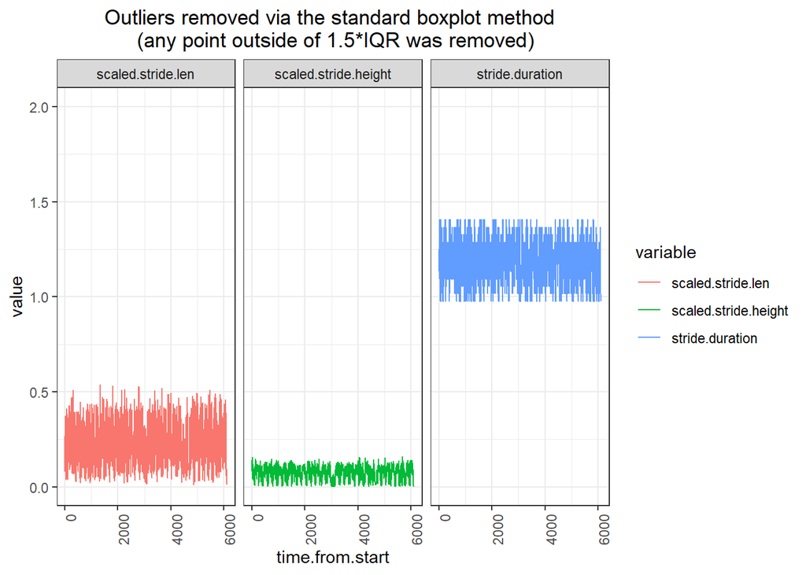

We could have tried making the value of the coefficient multiplied by the IQR coefficient larger (e.g., both the *tsoutlier() function* in the forecast package and the *iqr() function* in the anomalize package use a value of 3 for the coefficient); however, we did not explore this option since this: (a) would have possibly required a large amount of trial-and-error, and (b) the approach would be difficult to justify.

#### P8

**% of removed Observations for Partcipant 8: 5.1%.** This removes any value outside 1.5 * IQR for any of the 3 features. From the code, it should be clear that we are implementing this columnwise, starting with stride length and ending with stride duration.

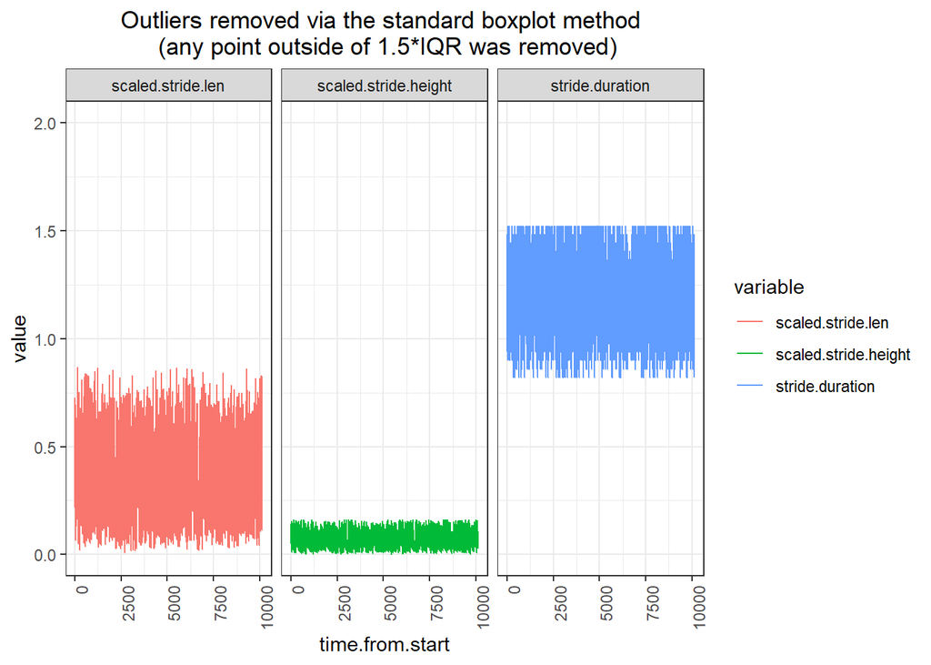

We could have tried making the value of the coefficient multiplied by the IQR coefficient larger (e.g., both the *tsoutlier() function* in the forecast package and the *iqr() function* in the anomalize package use a value of 3 for the coefficient); however, we did not explore this option since this: (a) would have possibly required a large amount of trial-and-error, and (b) the approach would be difficult to justify.

#### P9

**% of removed Observations for Partcipant 9: 9.04%.** This removes any value outside 1.5 * IQR for any of the 3 features. From the code, it should be clear that we are implementing this columnwise, starting with stride length and ending with stride duration.

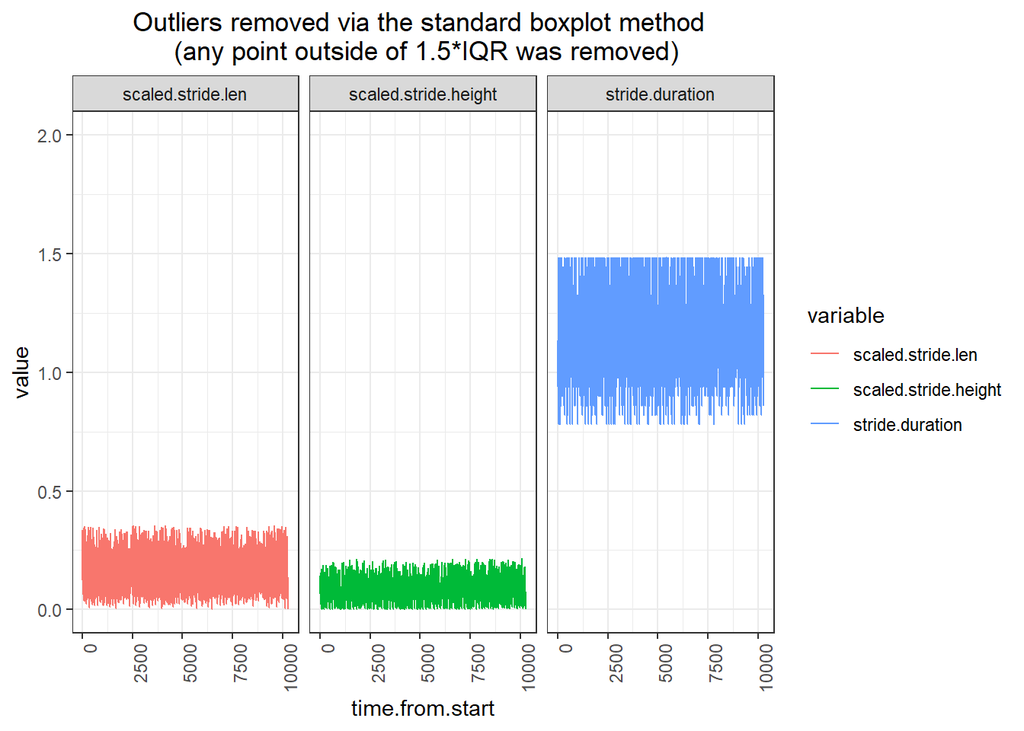

We could have tried making the value of the coefficient multiplied by the IQR coefficient larger (e.g., both the *tsoutlier() function* in the forecast package and the *iqr() function* in the anomalize package use a value of 3 for the coefficient); however, we did not explore this option since this: (a) would have possibly required a large amount of trial-and-error, and (b) the approach would be difficult to justify.

#### P10

**% of removed Observations for Partcipant 10: 12.6%.** This removes any value outside 1.5 * IQR for any of the 3 features. From the code, it should be clear that we are implementing this columnwise, starting with stride length and ending with stride duration.

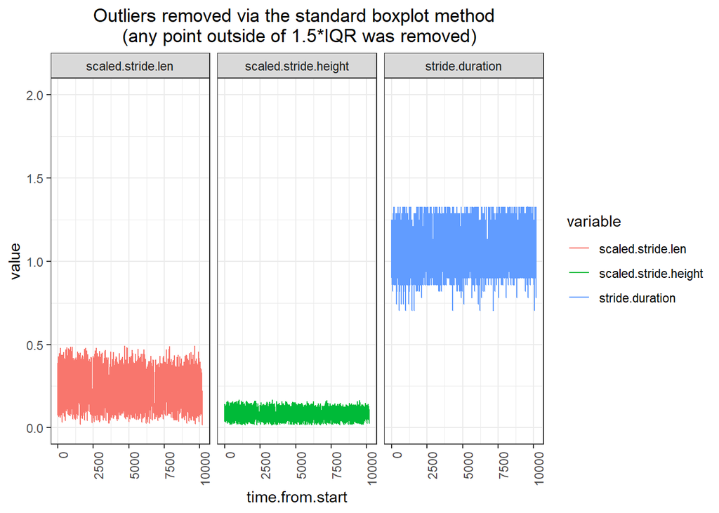

We could have tried making the value of the coefficient multiplied by the IQR coefficient larger (e.g., both the *tsoutlier() function* in the forecast package and the *iqr() function* in the anomalize package use a value of 3 for the coefficient); however, we did not explore this option since this: (a) would have possibly required a large amount of trial-and-error, and (b) the approach would be difficult to justify.

#### P11

**% of removed Observations for Partcipant 11: 23.66%.** This removes any value outside 1.5 * IQR for any of the 3 features. From the code, it should be clear that we are implementing this columnwise, starting with stride length and ending with stride duration.

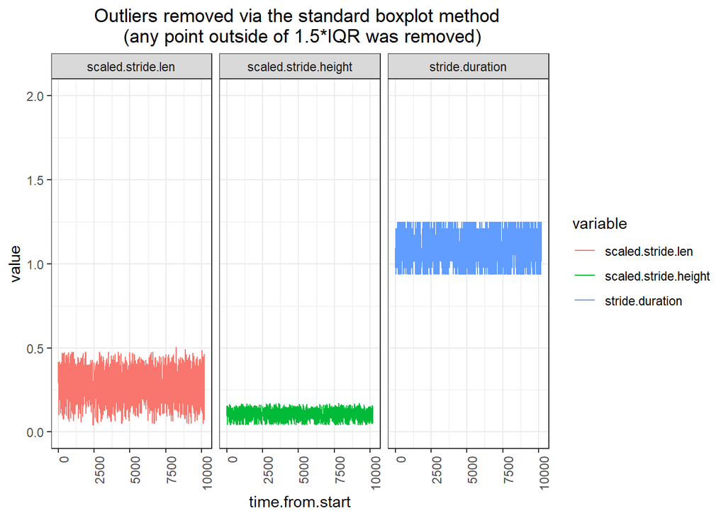

We could have tried making the value of the coefficient multiplied by the IQR coefficient larger (e.g., both the *tsoutlier() function* in the forecast package and the *iqr() function* in the anomalize package use a value of 3 for the coefficient); however, we did not explore this option since this: (a) would have possibly required a large amount of trial-and-error, and (b) the approach would be difficult to justify.

#### P12

**% of removed Observations for Partcipant 12: 12.14%.** This removes any value outside 1.5 * IQR for any of the 3 features. From the code, it should be clear that we are implementing this columnwise, starting with stride length and ending with stride duration.

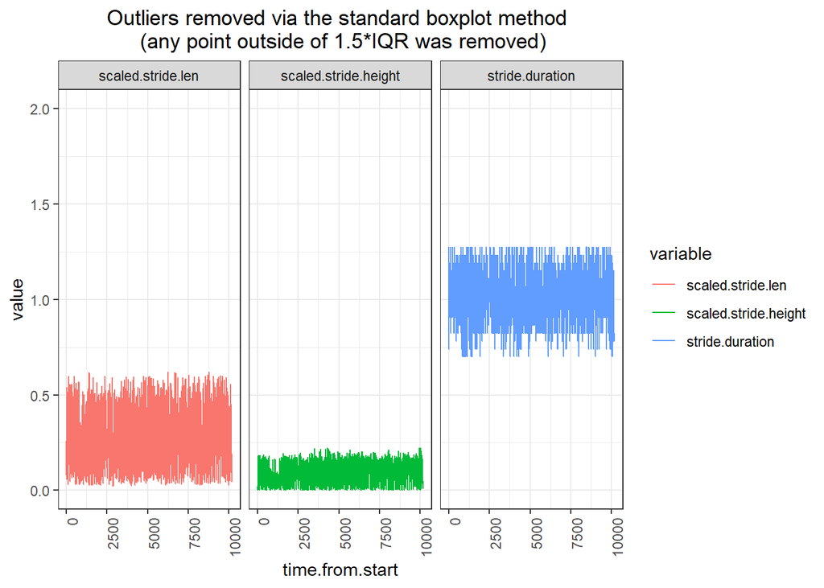

We could have tried making the value of the coefficient multiplied by the IQR coefficient larger (e.g., both the *tsoutlier() function* in the forecast package and the *iqr() function* in the anomalize package use a value of 3 for the coefficient); however, we did not explore this option since this: (a) would have possibly required a large amount of trial-and-error, and (b) the approach would be difficult to justify.

#### P13

**% of removed Observations for Partcipant 13: 11.99%.** This removes any value outside 1.5 * IQR for any of the 3 features. From the code, it should be clear that we are implementing this columnwise, starting with stride length and ending with stride duration.

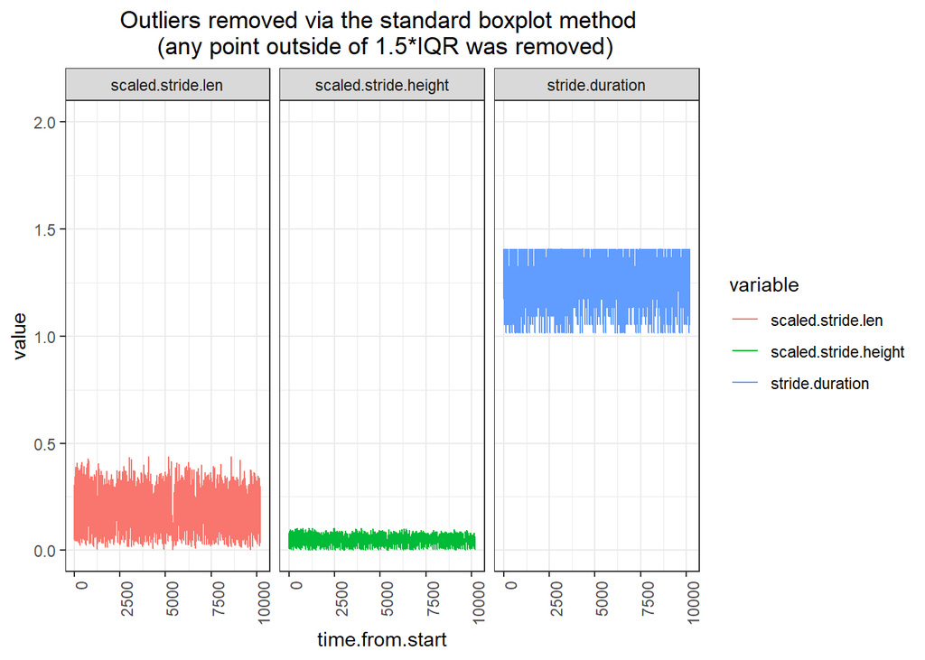

We could have tried making the value of the coefficient multiplied by the IQR coefficient larger (e.g., both the *tsoutlier() function* in the forecast package and the *iqr() function* in the anomalize package use a value of 3 for the coefficient); however, we did not explore this option since this: (a) would have possibly required a large amount of trial-and-error, and (b) the approach would be difficult to justify.

#### P14

**% of removed Observations for Partcipant 14: 9.33%.** This removes any value outside 1.5 * IQR for any of the 3 features. From the code, it should be clear that we are implementing this columnwise, starting with stride length and ending with stride duration.

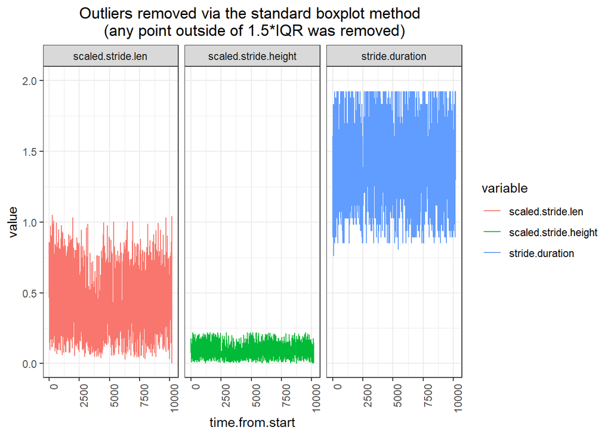

We could have tried making the value of the coefficient multiplied by the IQR coefficient larger (e.g., both the *tsoutlier() function* in the forecast package and the *iqr() function* in the anomalize package use a value of 3 for the coefficient); however, we did not explore this option since this: (a) would have possibly required a large amount of trial-and-error, and (b) the approach would be difficult to justify.

#### P15

**% of removed Observations for Partcipant 15: 14.24%.** This removes any value outside 1.5 * IQR for any of the 3 features. From the code, it should be clear that we are implementing this columnwise, starting with stride length and ending with stride duration.

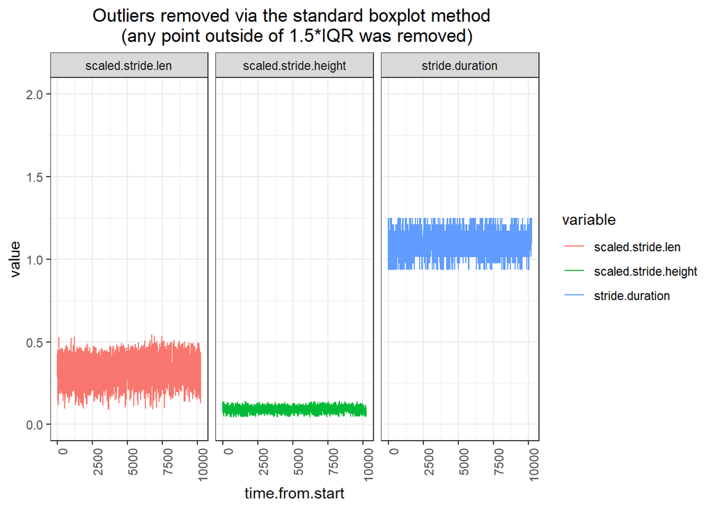

We could have tried making the value of the coefficient multiplied by the IQR coefficient larger (e.g., both the *tsoutlier() function* in the forecast package and the *iqr() function* in the anomalize package use a value of 3 for the coefficient); however, we did not explore this option since this: (a) would have possibly required a large amount of trial-and-error, and (b) the approach would be difficult to justify.

```r
# Saving a list of cleaned
save(subject1_bp, subject2_bp, subject3_bp, subject4_bp,
     subject5_bp, subject6_bp, subject7_bp, subject8_bp,
     subject9_bp, subject10_bp, subject11_bp, subject12_bp,
     subject13_bp, subject14_bp, subject15_bp, outliers_bp,
     file = "./Data/RGenerated/OutliersRemovedBoxplot.RData")
```

### 2.2.2 Mahalanobis Dist. based Method

```r
# We are reading the data locally (you can download the file from GitHub)
load(file = "./Data/RGenerated/FeatureGeneration.RData")
mal_results <- {}
for (i in 1:15) {
  df <- get(paste0("subject",i,"_features"))
  df <- df[,2:4]#only taking the four numeric fields
  cat('####',paste0("P", i), "{-}",' \n')
  cat('The output from the <source> <i> MVN package </i> </source> is shown below. Note that we depict the multivariate normal distribution for the three features of each distribution below. </source> <b> Essentially, the goal here is two-fold. First, we would like to examine if the joint distribution of the three kinematic features can be modeled using the multivariate normal distribution. Second, if the first hypothesis is true, then we can use the Mahalanobis Distance to identify outliers in each observation. </b> </source>')

  plot.new()
  mvn_test <- mvn(df, mvnTest = "dh",desc = TRUE,
                univariateTest = "Lillie",
                multivariateOutlierMethod = "adj",
                showOutliers = TRUE) #adjusted Mahl Distance
 cat(' \n')

  cat(paste0('In addition to the plot, we provide the statistics of the Doornik-Hansen test for Participant ',i,' below. \n \n'))
 mvn_Normality <- mvn_test$multivariateNormality
 rownames(mvn_Normality) <- paste('Participant',i)
 tab <- xtable::xtable(mvn_test$multivariateNormality,
                       align = c("c","c","c","c","c","c"))
 print(tab, type= 'html',
       html.table.attributes = 'align="center", rules="rows",
                                width=50%, frame="below"')
  cat('<source> <p> \n </p> </source>')

  cat(paste0('Based on the MVN test and the plot above, it is clear that the data is not normally distributed. Thus, an outlier detection/removal algorithm based on a MVN distribution will be inappropriate. This observation is true to not only Participant ', i, ' but to also all the other participants. Thus, in the following section we will investigate method(s) based on the time-series outlier detection literature.'))

  cat(' \n \n')

}
```

#### P1

The output from the *MVN package* is shown below. Note that we depict the multivariate normal distribution for the three features of each distribution below. **Essentially, the goal here is two-fold. First, we would like to examine if the joint distribution of the three kinematic features can be modeled using the multivariate normal distribution. Second, if the first hypothesis is true, then we can use the Mahalanobis Distance to identify outliers in each observation.**

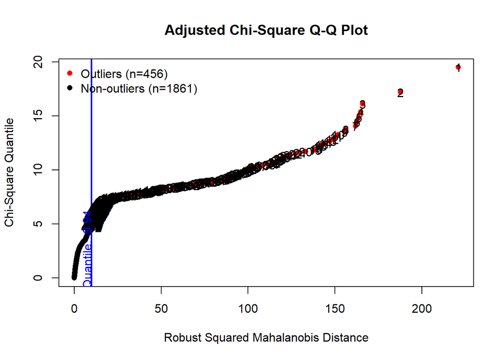

In addition to the plot, we provide the statistics of the Doornik-Hansen test for Participant 1 below.

|  | Test | E | df | p value | MVN |
| --- | --- | --- | --- | --- | --- |
| 1 | Doornik-Hansen | 4549.14 | 6.00 | 0.00 | NO |

Based on the MVN test and the plot above, it is clear that the data is not normally distributed. Thus, an outlier detection/removal algorithm based on a MVN distribution will be inappropriate. This observation is true to not only Participant 1 but to also all the other participants. Thus, in the following section we will investigate method(s) based on the time-series outlier detection literature.

#### P2

The output from the *MVN package* is shown below. Note that we depict the multivariate normal distribution for the three features of each distribution below. **Essentially, the goal here is two-fold. First, we would like to examine if the joint distribution of the three kinematic features can be modeled using the multivariate normal distribution. Second, if the first hypothesis is true, then we can use the Mahalanobis Distance to identify outliers in each observation.**

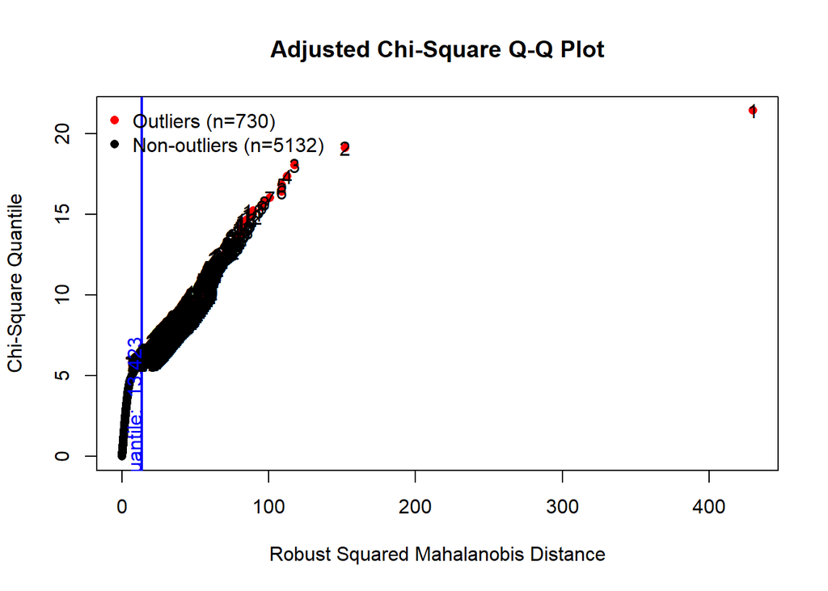

In addition to the plot, we provide the statistics of the Doornik-Hansen test for Participant 2 below.

|  | Test | E | df | p value | MVN |
| --- | --- | --- | --- | --- | --- |
| 1 | Doornik-Hansen | 6259.91 | 6.00 | 0.00 | NO |

Based on the MVN test and the plot above, it is clear that the data is not normally distributed. Thus, an outlier detection/removal algorithm based on a MVN distribution will be inappropriate. This observation is true to not only Participant 2 but to also all the other participants. Thus, in the following section we will investigate method(s) based on the time-series outlier detection literature.